# de Jong et al (2018)

# Estimating broad-sense heritabilities

This document contains the code to estimate heritabilities using linear mixed models. The implementation is similar to the one presented in a separate document titled “01_variance_partitioning.Rmd”, where we partitioned phenotypic variance into genetic and non-genetic components.

In this case, heritabilities are estimated for each N treatment separately, so the models used here are simpler, generally in the form:

$Y = G + \epsilon$

Where ‘G’ is the random genotype contribution (line ID), and $\epsilon$ is the residual error. We assume these components have a gaussian distribution, such that $G \sim N(0, \sigma_G)$ and $R \sim N(0, \sigma_R)$.

As we will see below, the linear model assumptions are not always well respected, but we hope to mitigate this somewhat by providing confidence intervals for our estimates.

We estimate two types of heritability (see [Nakagawa & Schielzeth 2010](http://onlinelibrary.wiley.com/doi/10.1111/j.1469-185X.2010.00141.x/full) and [Kover .. Mott 2009](http://journals.plos.org/plosgenetics/article?id=10.1371/journal.pgen.1000551)):

1. Broad-sense heritability (H2), which we take as being well estimated from the “clonal repeatability”" of individual measurements on our inbred lines.
2. An upper limit to narrow-sense heritability (h2_upper), or the repeatability of measurement means.

In this case, h2_upper will always be higher than H2, which is counter-intuitive since broad-sense heritability includes both additive and non-additive components of phenotypic variance, whereas narrow-sense heritability refers to the additive component phenotypic variance only. However, heritability would be based on the average phenotype of an individual, which thus reduces error variance (the denominator of heritability partitioning h = Vp / (Vp + Ve)).

Below, we first present the result for a few of the traits, to demonstrate some of the caveats with model assumptions. We then have code that estimates the heritability for all traits, which are combined into a single table, for plotting.

```r
library(tidyverse)
library(patchwork)
library(lme4)

# Change ggplot2 default aesthetics
theme_set(theme_classic() +
            theme(panel.grid = element_blank(),
                  text = element_text(size = 8),
                  plot.title = element_text(hjust = -0.07, size = 10, face = "bold",
                                            margin = margin(t = -5, b = 1)),
                  plot.subtitle = element_text(size = 10, hjust = 0.5)))

# Source some custom functions
source("./functions/repeatHeritability.R")
source("./functions/plotLmmDiag.R")
```

## Read data

There are two main datasets: accessions and MAGIC lines.

Here we read individual data, which can be used to estimate repeatabilities.

```r
# Read MAGIC line data
magic_ind <- read_rds("../../data/phenotypes/magic_individual.rds") %>%
  mutate(id_leyser = as.character(id_leyser))

# Read Accession data (note there is also senescence data for this set)
acc_ind <- read_rds("../../data/phenotypes/accessions_individual.rds") %>%
  filter(set == "silique")

acc_ind_sen <- read_rds("../../data/phenotypes/accessions_individual.rds") %>%
  filter(set == "senescence")
```

We also create a vector containing the lines that flower, on average, before 25 days on LN:

```r
early_magic <- read_rds("../../data/phenotypes/magic_plasticity.rds") %>%
  filter(bolt_mean_ln < 25) %>% .$id_leyser

early_acc <- read_rds("../../data/phenotypes/accessions_plasticity.rds") %>%
  filter(set == "silique" & bolt_mean_ln < 25) %>% .$id_leyser
```

## Model details

Before calculating estimates of heritability presented in the paper, we want to explicitly demonstrate the model that is being fitted and its diagnostics.

In particular, we discuss flowering time (days to bolt) because the model diagnostics are improved by transforming the data.

### Height

We start with height, which is the trait that best approximates a normal distribution:

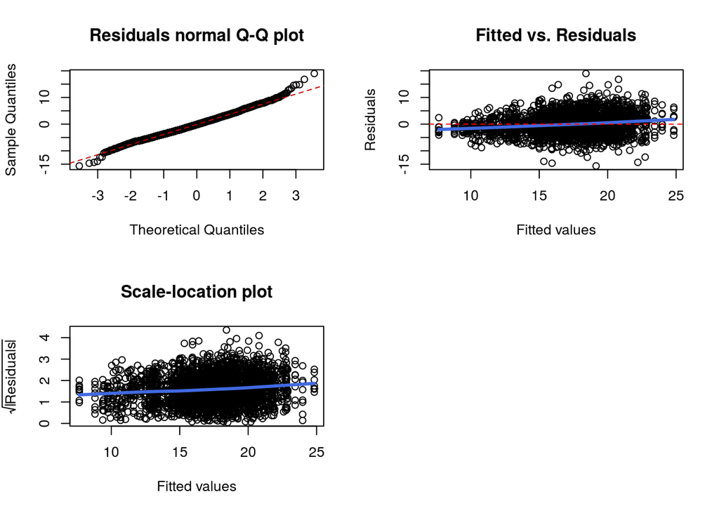

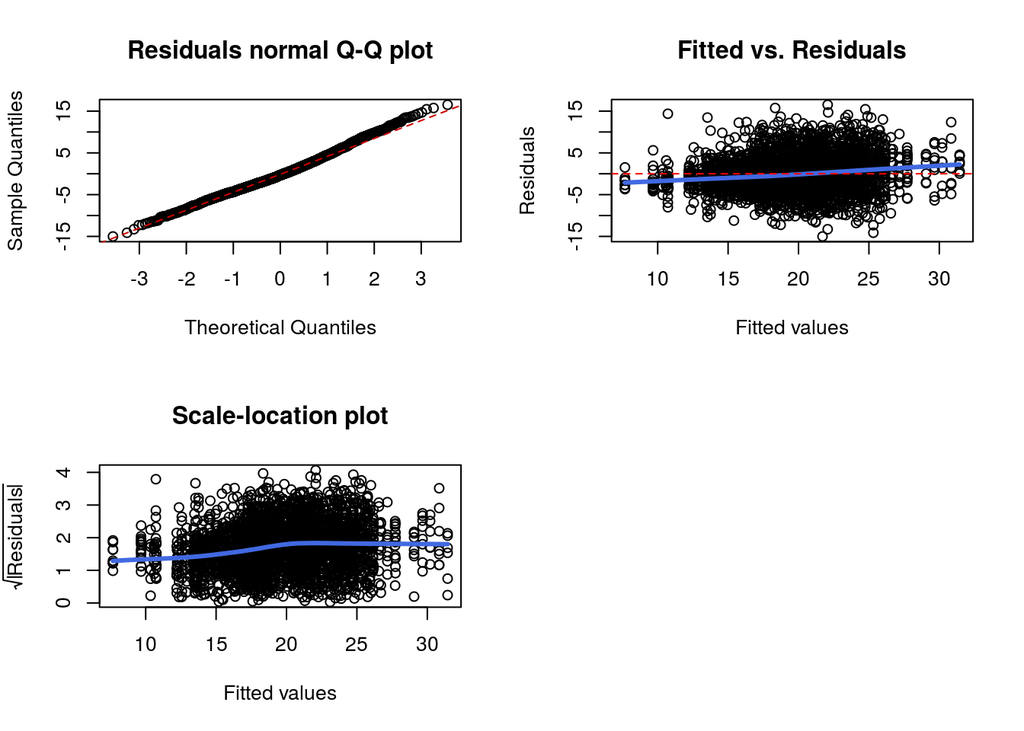

```r
# The following pipe filters data to include only one of the nitrate treatments
# Then fits the model that will be used to extract variance components
# and finally produces some diagnostic plots for the model
magic_ind %>%
  filter(nitrate == "LN") %>%
  lmer(height ~ (1|id_leyser), data = .) %>%
  plotLmmDiag()
magic_ind %>%
  filter(nitrate == "HN") %>%
  lmer(height ~ (1|id_leyser), data = .) %>%
  plotLmmDiag()
```

These diagnostics show that the residuals are well approximated by a normal distribution (with some deviations at the tails) and that there is no extreme heteroskedasticity in the data (the trend line on the scale-location plot is relatively flat).

### Days to bolt

For flowering time, the diagnostics reveal some issues:

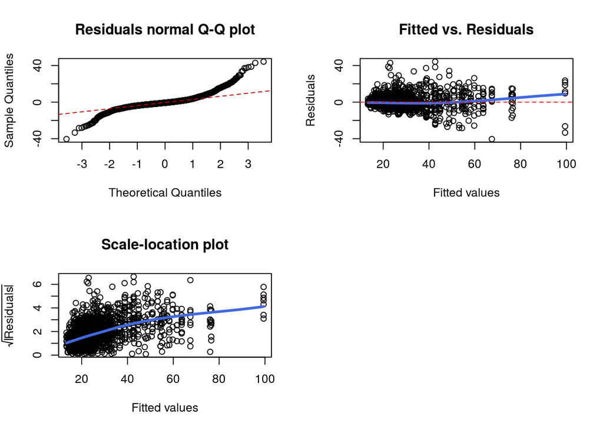

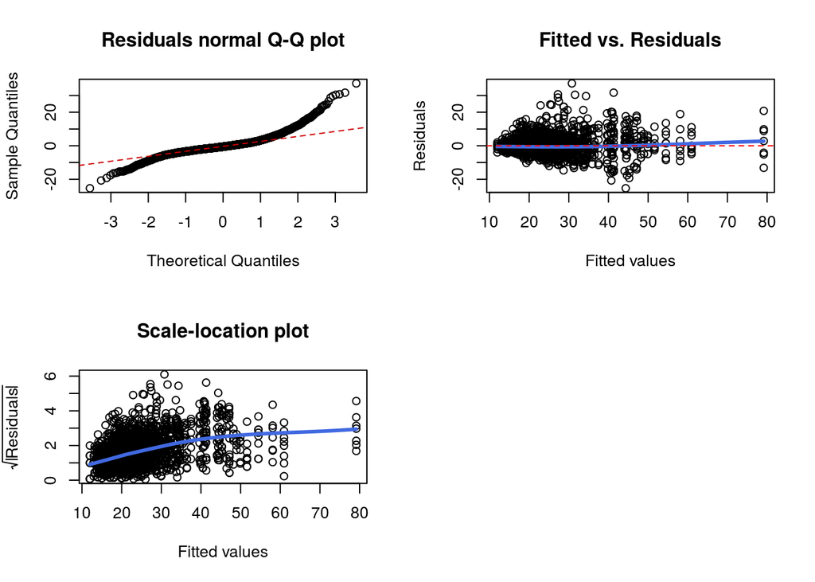

```r
magic_ind %>%
  filter(nitrate == "LN") %>%
  lmer(bolt ~ (1|id_leyser), data = .) %>%
  plotLmmDiag()

magic_ind %>%
  filter(nitrate == "HN") %>%
  lmer(bolt ~ (1|id_leyser), data = .) %>%
  plotLmmDiag()
```

Not only do the residuals deviate from normality at the tails of the distribution, but there’s also a clear sign that the variance increases with the fitted values (blue trend line on scale-location plots).

This is ammeliorated by log-transforming the data:

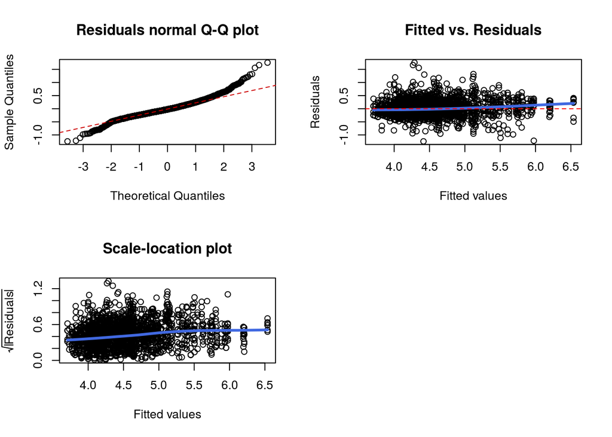

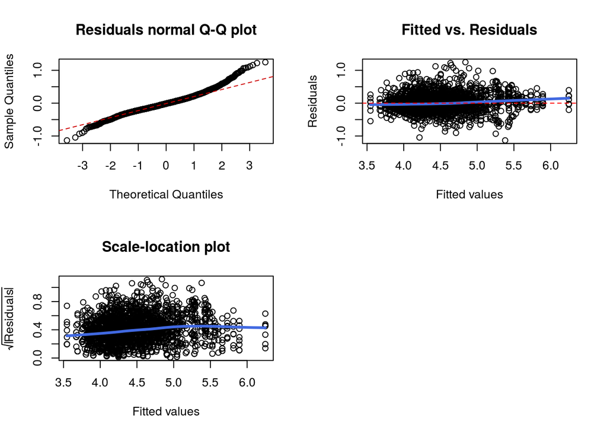

```r
magic_ind %>%
  filter(nitrate == "LN") %>%
  lmer(log2(bolt) ~ (1|id_leyser), data = .) %>%
  plotLmmDiag()

magic_ind %>%
  filter(nitrate == "HN") %>%
  lmer(log2(bolt) ~ (1|id_leyser), data = .) %>%
  plotLmmDiag()
```

Although the residuals still have some departure from normality, the scale-location plot seems to have a flatter trend line, suggesting that the variance has been somewhat stabilized across the range of fitted values. We therefore estimate heritability based on log-transformed days to bolt.

```r
# log-transform flowering time
magic_ind <- mutate(magic_ind, bolt = log2(bolt))
```

### Shoot branching

Despite being count data, for shoot branches the diagnostics look reasonable:

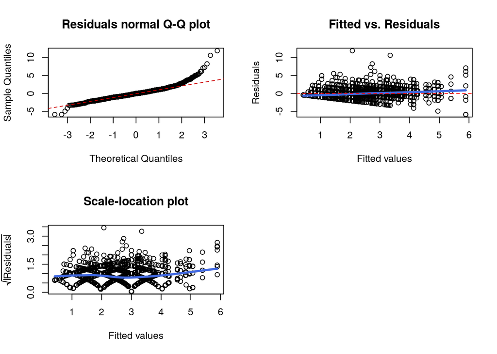

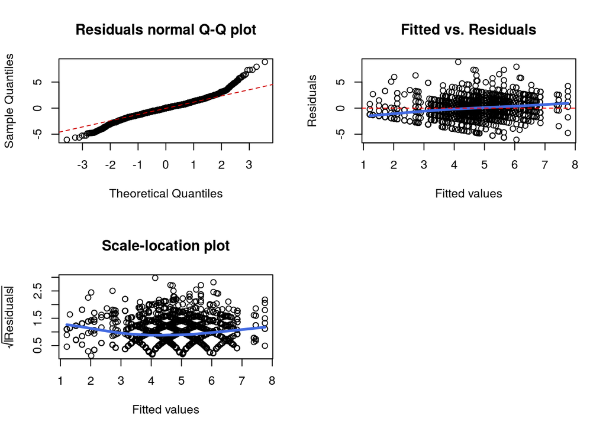

```r
magic_ind %>%
  filter(nitrate == "LN") %>%
  lmer(totalbr ~ (1|id_leyser), data = .) %>%
  plotLmmDiag()

magic_ind %>%
  filter(nitrate == "HN") %>%
  lmer(totalbr ~ (1|id_leyser), data = .) %>%
  plotLmmDiag()
```

Square-root transformation of the data does not seem to improve this (in fact, it seems to make it worse):

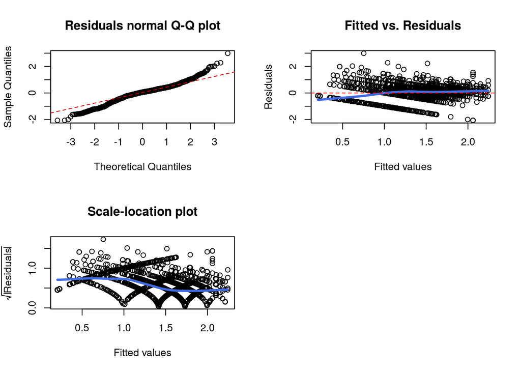

```r
magic_ind %>%
  filter(nitrate == "LN") %>%
  lmer(sqrt(totalbr) ~ (1|id_leyser), data = .) %>%
  plotLmmDiag()
```

We therefore use the model on non-transformed data.

## Heritability estimates for all traits

We have written a function that estimates genetic and residual variance from the models fitted as exemplified above. The function can produce diagnostic plots for the linear model, to assess its suitability. In this section we do not produce these plots for all traits, as we already highlighted the main issues above.

The function also provides with a 95% confidence interval for the heritability estimates, using a parametric bootstrap approach (see [Kluen & Brommer 2013](https://doi.org/10.1093/beheco/ars221)).

First we make a list of all the phenotypes and respective genotypes for different sets of data:

```r
# Make list of phenotypes and respective genotypes to estimate heritabilities
## naming convention is "population_trait_stage_flowering", where:
## population: either MAGIC lines or Accessions
## trait: bolt, height, total branches, total siliques
## stage: 2-silique or senescence
## flowering: all lines or only early flowering lines (<25 days)
traits <- list(
  magic_bolt_sil_all = magic_ind %>% select(nitrate, id_leyser, bolt),
  magic_bolt_sil_early = magic_ind %>% filter(id_leyser %in% early_magic) %>% select(nitrate, id_leyser, bolt),
  magic_height_sil_all = magic_ind %>% select(nitrate, id_leyser, height),
  magic_height_sil_early = magic_ind %>% filter(id_leyser %in% early_magic) %>% select(nitrate, id_leyser, height),
  magic_totalbr_sil_all = magic_ind %>% select(nitrate, id_leyser, totalbr),
  magic_totalbr_sil_early = magic_ind %>% filter(id_leyser %in% early_magic) %>% select(nitrate, id_leyser, totalbr),
  acc_bolt_sil_all = acc_ind %>% select(nitrate, id_leyser, bolt),
  acc_bolt_sil_early = acc_ind %>% filter(id_leyser %in% early_acc) %>% select(nitrate, id_leyser, bolt),
  acc_height_sil_all = acc_ind %>% select(nitrate, id_leyser, height),
  acc_height_sil_early = acc_ind %>% filter(id_leyser %in% early_acc) %>% select(nitrate, id_leyser, height),
  acc_totalbr_sil_all = acc_ind %>% select(nitrate, id_leyser, totalbr),
  acc_totalbr_sil_early = acc_ind %>% filter(id_leyser %in% early_acc) %>% select(nitrate, id_leyser, totalbr),
  acc_totalbr_sen_all = acc_ind_sen %>% select(nitrate, id_leyser, totalbr),
  acc_totalbr_sen_early = acc_ind_sen %>% filter(id_leyser %in% early_acc) %>% select(nitrate, id_leyser, totalbr),
  acc_totalsil_sen_all = acc_ind_sen %>% select(nitrate, id_leyser, totalsil),
  acc_totalsil_sen_early = acc_ind_sen %>% filter(id_leyser %in% early_acc) %>% select(nitrate, id_leyser, totalsil)
)
```

We now loop through this list and estimate heritabilities using our custom function. We do this separately for HN and LN:

```r
# Because the code below takes long to run, we only run it if the output file
# does not already exist

# Create output directory
if(!dir.exists("./temp_data/")) dir.create("./temp_data")

# Fit model
if(!file.exists("./temp_data/all_trait_heritabilities.csv")){

  # Loop through list to calculate heritabilities
  hers <- lapply(traits, function(x){
    names(x) <- c("nitrate", "genotype", "phenotype")
    x %>%
      group_by(nitrate) %>%
      do(repeatHeritability(.$phenotype, .$genotype, plot_diag = FALSE,
                            ci = 0.95, nboot = 1000, ncores = 2))
  })

  # Combine and tidy all tables
  hers <- bind_rows(hers, .id = "set") %>%
    separate(set, c("pop", "trait", "stage", "flowering"), sep = "_")

  # Save this table to avoid re-computing
  write_csv(hers, "./temp_data/all_trait_heritabilities.csv")

} else {
  # If the file exists, read it
  hers <- read_csv("./temp_data/all_trait_heritabilities.csv")
}
```

Sample sizes in each combination:

```r
temp <- map(traits, function(x){
  names(x) <- c("nitrate", "genotype", "phenotype")
  x %>%
    filter(!is.na(phenotype) & !is.na(genotype)) %>%
    count(nitrate, genotype) %>%
    summarise(min = min(n), max = max(n), med = median(n), n = length(unique(genotype)))
})

bind_rows(temp, .id = "trait")
```

```
## # A tibble: 16 x 5
##    trait                     min   max   med     n
##    <chr>                   <dbl> <dbl> <dbl> <int>
##  1 magic_bolt_sil_all       3.00  8.00  7.00   374
##  2 magic_bolt_sil_early     3.00  8.00  8.00   258
##  3 magic_height_sil_all     4.00  8.00  7.00   374
##  4 magic_height_sil_early   4.00  8.00  8.00   258
##  5 magic_totalbr_sil_all    4.00  8.00  7.00   374
##  6 magic_totalbr_sil_early  4.00  8.00  8.00   258
##  7 acc_bolt_sil_all         3.00  8.00  8.00   297
##  8 acc_bolt_sil_early       3.00  8.00  8.00   266
##  9 acc_height_sil_all       4.00  8.00  8.00   297
## 10 acc_height_sil_early     4.00  8.00  8.00   266
## 11 acc_totalbr_sil_all      4.00  8.00  8.00   297
## 12 acc_totalbr_sil_early    4.00  8.00  8.00   266
## 13 acc_totalbr_sen_all      4.00  8.00  8.00   278
## 14 acc_totalbr_sen_early    4.00  8.00  8.00   260
## 15 acc_totalsil_sen_all     4.00  8.00  8.00   278
## 16 acc_totalsil_sen_early   4.00  8.00  8.00   260
```

### Fig S4

This is the plot presented in the paper:

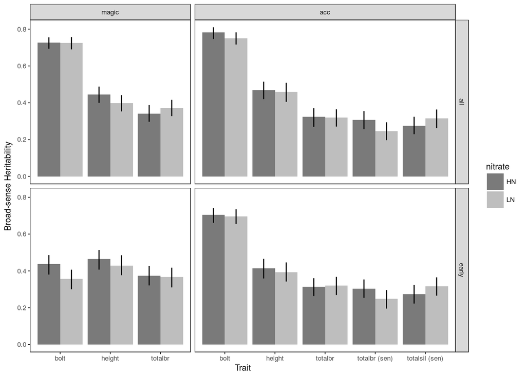

```r
#pdf("./figures/figureS4.pdf", width = 4.5, height = 2.5)
hers %>%
  mutate(pop = factor(pop, levels = c("magic", "acc")),
         trait = ifelse(stage == "sen", paste0(trait, " (sen)"), trait)) %>%
  ggplot(aes(trait, her_i, fill = nitrate)) +
  geom_bar(stat = "identity", position = "dodge") +
  geom_errorbar(aes(ymin = her_i_lo, ymax = her_i_hi), width = 0, position = position_dodge(0.9)) +
  facet_grid(flowering ~ pop, scales = "free_x", space = "free_x") +
  scale_fill_manual(values = c("grey48", "grey")) +
  labs(x = "Trait", y = "Broad-sense Heritability") +
  theme_bw(base_size = 8) +
  theme(panel.grid = element_blank())
```

```r
#dev.off()
```